# R Coding - Lecture 0: Introduction to RMarkdown

Marco Zanotti

## RMardown

So far, you’ve learned the tools to get your data into R, tidy it into a form convenient for analysis, and then understand your data through transformation, visualization and modelling. However, it doesn’t matter how great your analysis is unless you can explain it to others: you need to **communicate** your results.

R Markdown provides an authoring framework for data science.

You can use a single R Markdown file to both  
- save and execute code, and  
- generate high quality reports that can be shared with an audience.

R Markdown was designed for easier reproducibility, since both the computing code and narratives are in the same document, and results are automatically generated from the source code. R Markdown supports dozens of static and dynamic/interactive output formats.

There are three basic components of an R Markdown document: the metadata, text, and code. The metadata is written between the pair of three dashes —. The syntax for the metadata is YAML (YAML Ain’t Markup Language, https://en.wikipedia.org/wiki/YAML), so sometimes it is also called the YAML metadata or the YAML frontmatter.

The body of a document follows the metadata. The syntax for text (also known as prose or narratives) is Markdown.

### How to Create an RMarkdown Document

Open a new .Rmd file in the RStudio IDE by going to File > New File > R Markdown.

### RMarkdown Workflow

1. Open a new .Rmd file in the RStudio IDE by going to File > New File > R Markdown
2. Embed code in chunks. Run code by line, by chunk, or all at once.
3. Write text and add tables, figures, images, and citations  
   Format with Markdown syntax or the RStudio Visual Markdown Editor
4. Set output format(s) and options in the YAML header. Customize themes or add parameters to execute or add interactivity with Shiny
5. Save and render the whole document. Knit periodically to preview your work as you write
6. Share your work!

### Rendering

If you must render a document in the current R session, you can also call rmarkdown::render() by yourself, and pass the path of the Rmd file to this function. The second argument of this function is the output format, which defaults to the first output format you specify in the YAML metadata (if it is missing, the default is html_document).

There are two types of output formats in the rmarkdown package: documents, and presentations.

### Learning RMarkdown

To master RMarkdown follow [RMarkdown the Definitive Guide](https://bookdown.org/yihui/rmarkdown/)

If you prefer a video introduction to R Markdown, I recommend that you check out the website https://rmarkdown.rstudio.com, and watch the videos in the “Get Started” section, which cover the basics of R Markdown.

## Headers

To create a header to an RMarkdown document you can `#`. The number of `#` used represents the level of the header.

## Text

Text can simply be add writing normally as a text document.

**Bold text** is added with `**some text**` and *italic text* with `*some text*`.

One can also adapts the text to the output of an R command, such as ‘nrow(cars)’ and ‘ncol(cars)’. To include the output of an R command within the text, use backticks and r. For example… the iris dataset contains 150 rows and 5 columns.

## Comments

To add comments to an RMarkdown document you can use `<!-- some text -->`, as in html.

## Chunks

Chunks are the places where code is used and they are created with the following syntax

`` ```{r chunk_name} # some code ``` ``

Chunks can be inserted quickly using the keyboard shortcut Ctrl + Alt + I (macOS: Cmd + Option + I), or via the Insert menu in the editor toolbar.

Each chunk has a name. The name must be in the form ‘r + some text’, for instance ‘r data’. Within a chunk you can write R commands.

```r
str(iris)
```

```
## 'data.frame':    150 obs. of  5 variables:
##  $ Sepal.Length: num  5.1 4.9 4.7 4.6 5 5.4 4.6 5 4.4 4.9 ...
##  $ Sepal.Width : num  3.5 3 3.2 3.1 3.6 3.9 3.4 3.4 2.9 3.1 ...
##  $ Petal.Length: num  1.4 1.4 1.3 1.5 1.4 1.7 1.4 1.5 1.4 1.5 ...
##  $ Petal.Width : num  0.2 0.2 0.2 0.2 0.2 0.4 0.3 0.2 0.2 0.1 ...
##  $ Species     : Factor w/ 3 levels "setosa","versicolor",..: 1 1 1 1 1 1 1 1 1 1 ...
```

Chunks have options that controls how r commands and outputs are displayed in the html document. The are few fundamental options that are always used:  
- `eval`: whether to evaluate a code chunk.  
- `echo`: whether to echo the source code in the output document (someone may not prefer reading your smart source code but only results).  
- `include`: whether to include anything from a code chunk in the output document.  
- `warning`, `message`, and `error`: whether to show warnings, messages, and errors in the output document.  
- `fig.width` and `fig.height`: the (graphical device) size of R plots in inches.  
- `out.width` and `out.height`: the output size of R plots in the output document.  
- `fig.align`: the alignment of plots. It can be ‘left’, ‘center’, or ‘right’.  
- `fig.cap`: the figure caption.

## Figures

By default, figures produced by R code will be placed immediately after the code chunk they were generated from.

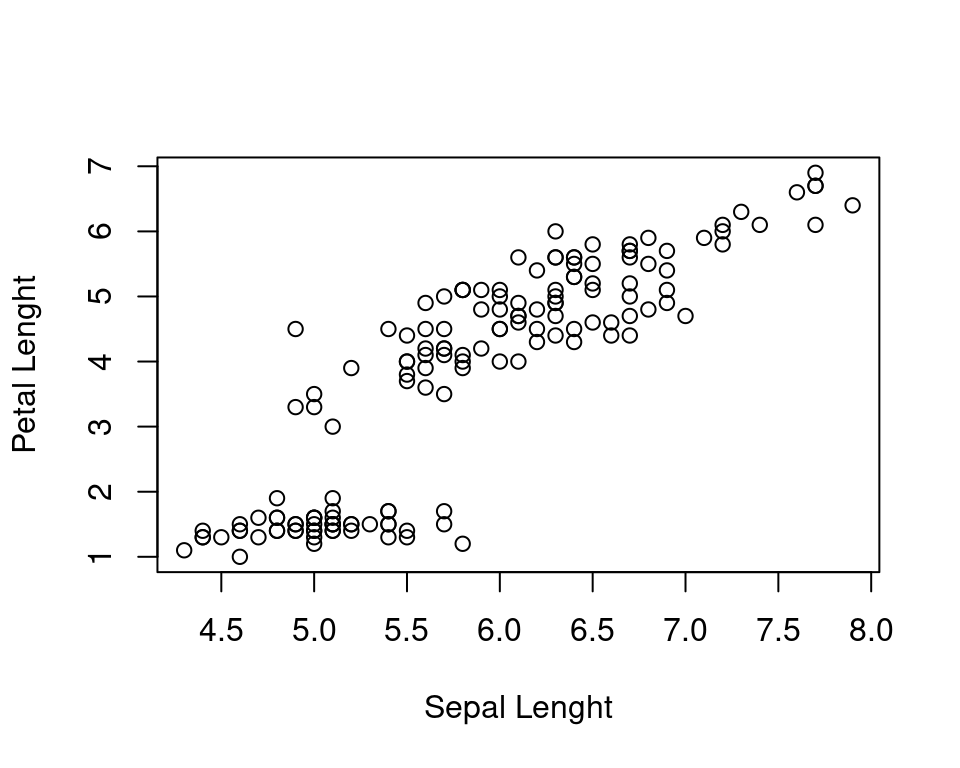

```r
plot(iris$Sepal.Length, iris$Petal.Length, xlab = "Sepal Lenght", ylab = "Petal Lenght")
```

## Statistics within Chunks

One can simply perform statistical analysis within code chunks.

```r
summary(iris)
```

```
##   Sepal.Length    Sepal.Width     Petal.Length    Petal.Width
##  Min.   :4.300   Min.   :2.000   Min.   :1.000   Min.   :0.100
##  1st Qu.:5.100   1st Qu.:2.800   1st Qu.:1.600   1st Qu.:0.300
##  Median :5.800   Median :3.000   Median :4.350   Median :1.300
##  Mean   :5.843   Mean   :3.057   Mean   :3.758   Mean   :1.199
##  3rd Qu.:6.400   3rd Qu.:3.300   3rd Qu.:5.100   3rd Qu.:1.800
##  Max.   :7.900   Max.   :4.400   Max.   :6.900   Max.   :2.500
##        Species
##  setosa    :50
##  versicolor:50
##  virginica :50
##
##
##
```

Math expression can be inserted by surrounding text into $.

I now want to fit the linear regression model to my data of the form

$$Y = \beta_0 + \beta_1 X +
\varepsilon$$

To do this, I simply use the function `lm`.

```r
model <- lm(Petal.Length ~ Sepal.Length, data = iris)
```

The model output is the following:

```r
summary(model)
```

```
##
## Call:
## lm(formula = Petal.Length ~ Sepal.Length, data = iris)
##
## Residuals:
##      Min       1Q   Median       3Q      Max
## -2.47747 -0.59072 -0.00668  0.60484  2.49512
##
## Coefficients:
##              Estimate Std. Error t value Pr(>|t|)
## (Intercept)  -7.10144    0.50666  -14.02   <2e-16 ***
## Sepal.Length  1.85843    0.08586   21.65   <2e-16 ***
## ---
## Signif. codes:  0 '***' 0.001 '**' 0.01 '*' 0.05 '.' 0.1 ' ' 1
##
## Residual standard error: 0.8678 on 148 degrees of freedom
## Multiple R-squared:   0.76,  Adjusted R-squared:  0.7583
## F-statistic: 468.6 on 1 and 148 DF,  p-value: < 2.2e-16
```

We see that $\hat{\beta}_0$ is -7.1 while the slope is equal to 1.86.